# BRFSS Data Profiling

# DC

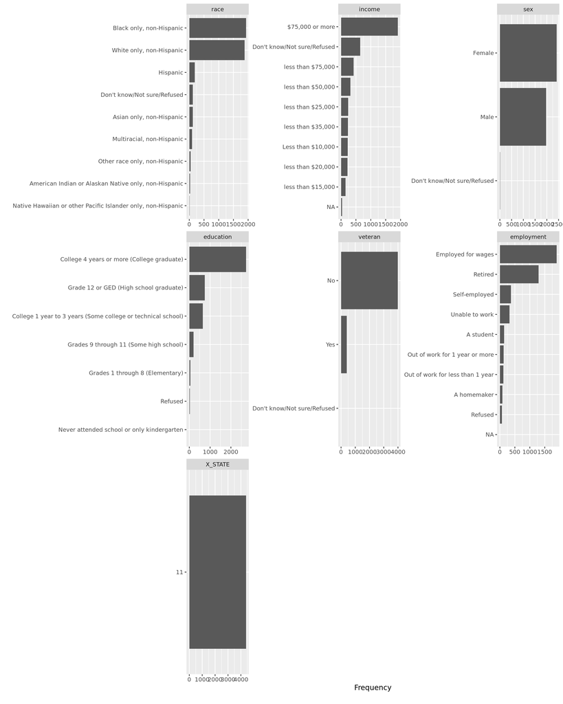

```r
dc <- brfss2018%>%
  filter(X_STATE == 11)  #DC is coded 11

#glimpse(brfss2018)
plot_bar(dc)
```

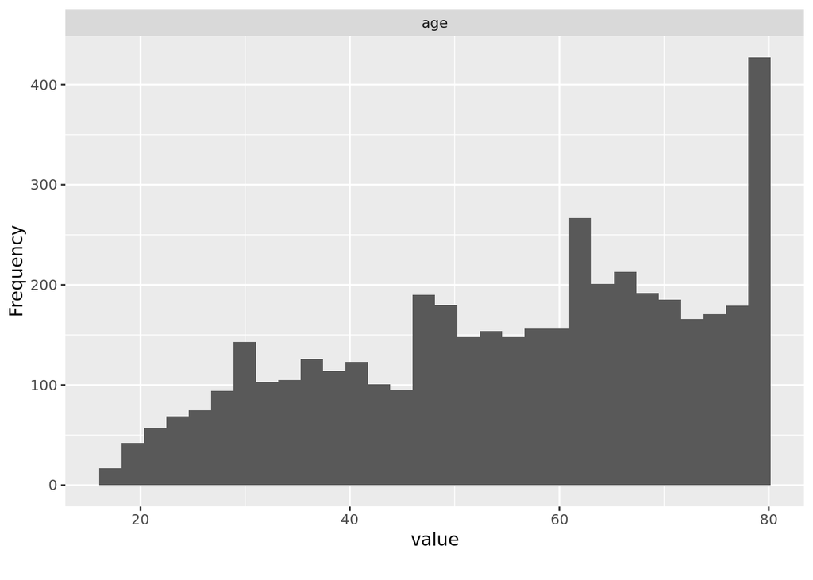

```r
plot_histogram(dc)
```

# Veteran/Age

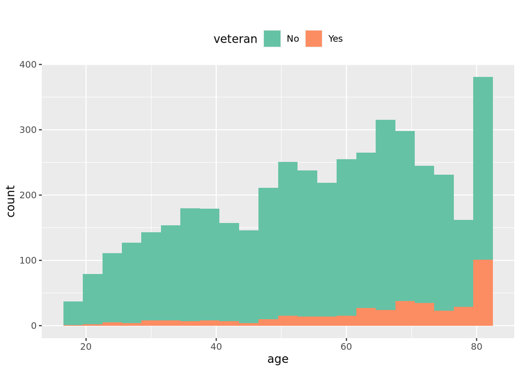

```r
dc_vet <- dc%>%
  filter(veteran %in% c("Yes", "No"))

ggplot(dc_vet, aes(x = age, fill = veteran)) +
  geom_histogram(binwidth = 3) +
 # aes(colour = veteran) +
  labs(title = "") +
  theme(legend.position = "top") +
  scale_fill_brewer(palette = "Set2")
```

# Veteran/Race

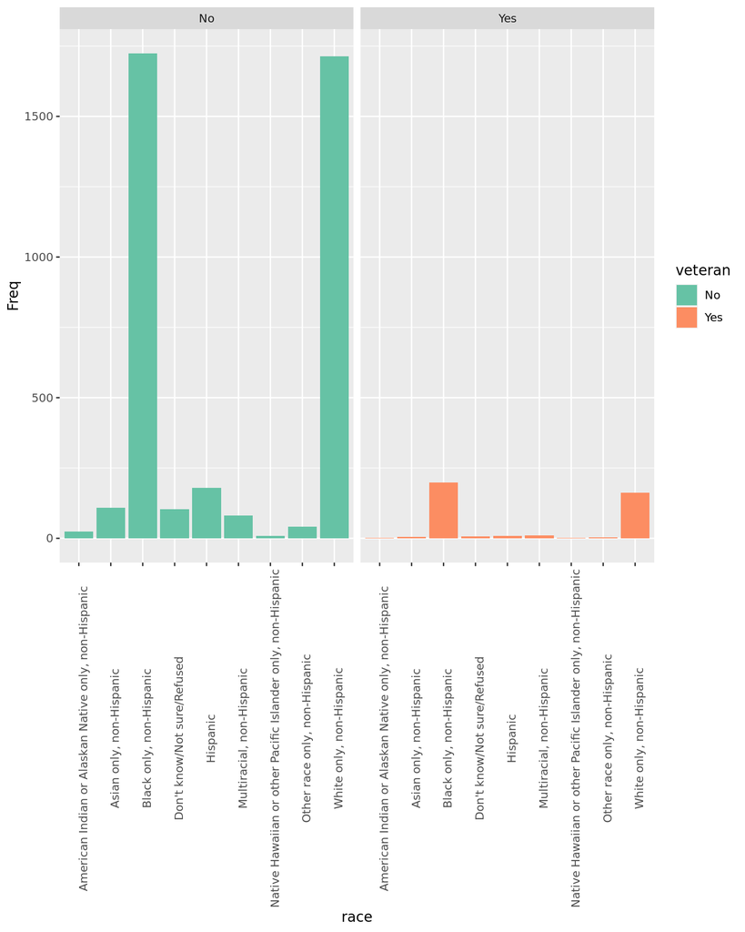

```r
vet_race <- table(dc_vet$veteran, dc_vet$race)%>%
  as.data.frame()%>%
  rename("veteran" = "Var1", "race" = "Var2")

ggplot(vet_race, aes(x = race, y = Freq))+
  geom_bar(aes(fill = veteran),
           stat = "identity")+
  scale_fill_brewer(palette = "Set2")+
  facet_wrap(~veteran) +
  theme(axis.text.x = element_text(angle = 90))
```

# Veteran/Education

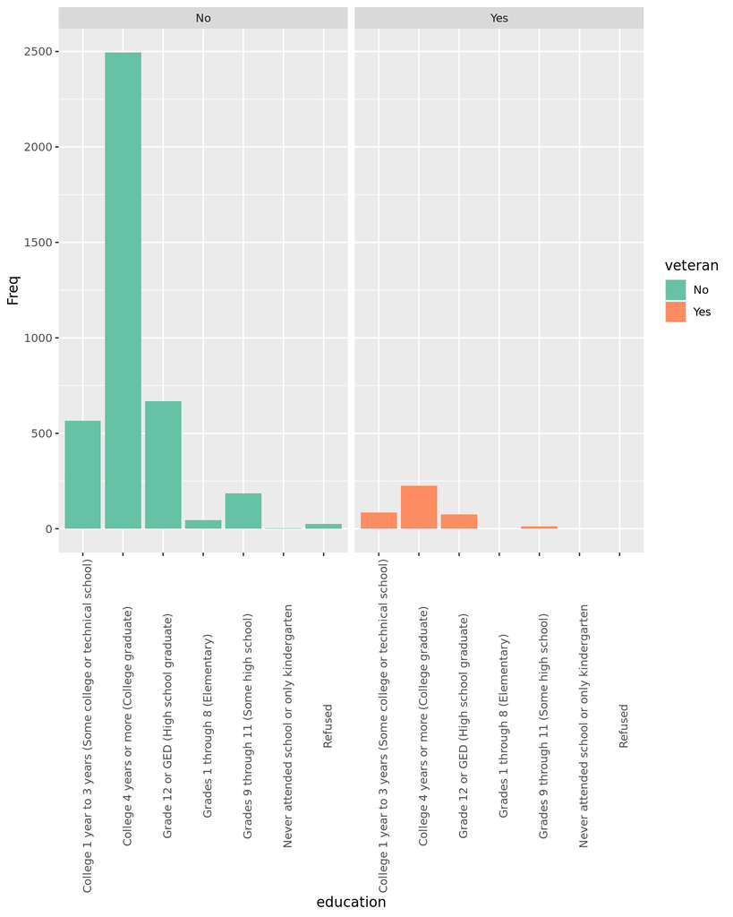

```r
vet_edu <- table(dc_vet$veteran, dc_vet$education)%>%
  as.data.frame()%>%
  rename("veteran" = "Var1", "education" = "Var2")

ggplot(vet_edu, aes(x = education, y = Freq))+
  geom_bar(aes(fill = veteran),
           stat = "identity")+
  scale_fill_brewer(palette = "Set2")+
  facet_wrap(~veteran) +
  theme(axis.text.x = element_text(angle = 90))
```

# Veteran/Gender

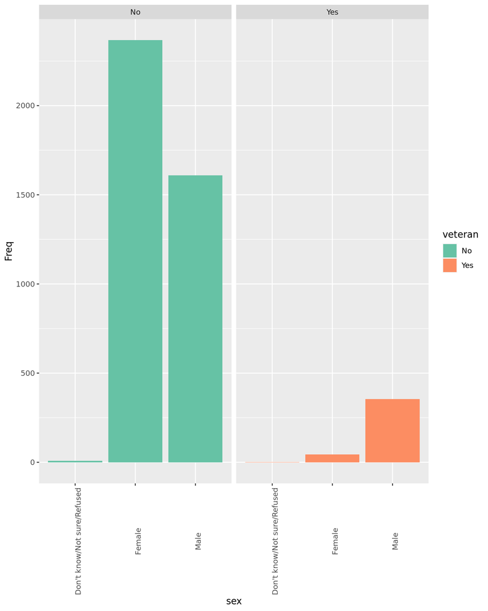

```r
vet_sex <- table(dc_vet$veteran, dc_vet$sex)%>%
  as.data.frame()%>%
  rename("veteran" = "Var1", "sex" = "Var2")

ggplot(vet_sex, aes(x = sex, y = Freq))+
  geom_bar(aes(fill = veteran),
           stat = "identity")+
  scale_fill_brewer(palette = "Set2")+
  facet_wrap(~veteran) +
  theme(axis.text.x = element_text(angle = 90))
```

# Veteran/Employment

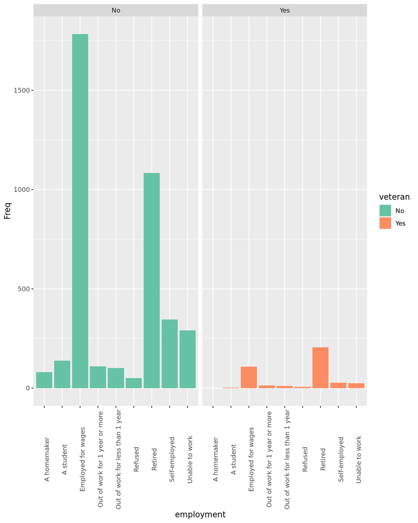

```r
vet_emp <- table(dc_vet$veteran, dc_vet$employment)%>%
  as.data.frame()%>%
  rename("veteran" = "Var1", "employment" = "Var2")

ggplot(vet_emp, aes(x = employment, y = Freq))+
  geom_bar(aes(fill = veteran),
           stat = "identity")+
  scale_fill_brewer(palette = "Set2")+
  facet_wrap(~veteran) +
  theme(axis.text.x = element_text(angle = 90))
```

# Veteran/Income

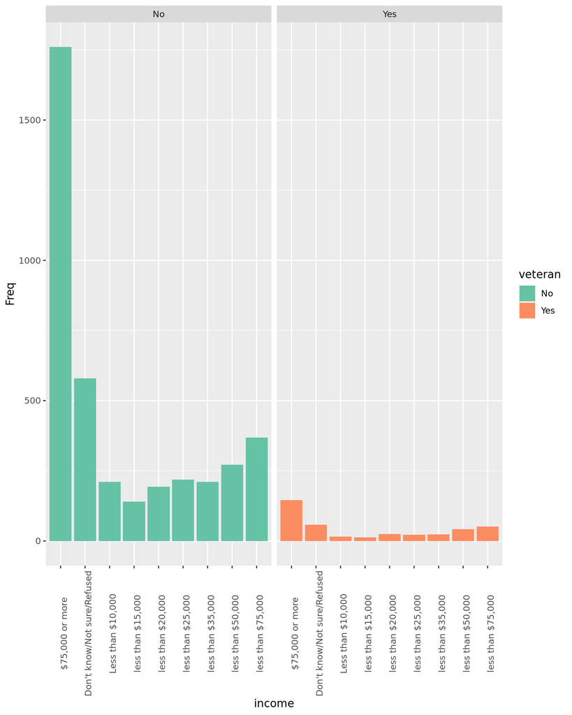

```r
vet_income <- table(dc_vet$veteran, dc_vet$income)%>%
  as.data.frame()%>%
  rename("veteran" = "Var1", "income" = "Var2")

ggplot(vet_income, aes(x = income, y = Freq))+
  geom_bar(aes(fill = veteran),
           stat = "identity")+
  scale_fill_brewer(palette = "Set2")+
  facet_wrap(~veteran) +
  theme(axis.text.x = element_text(angle = 90))
```